# Datenvisualisierung mit R

Einführung

Armin Schäfer

schaefer@politik.uni-mainz.de

17.04.2025

## Was wir heute vorhaben

1. Vorstellungsrunde
2. The bad, the ugly and the wrong
3. Erste Merkposten
4. Ziele der Lehrveranstaltung und Ablauf
5. Was Sie tun müssen
6. R und RStudio laden

## Hilfe! Meine Augen schmerzen

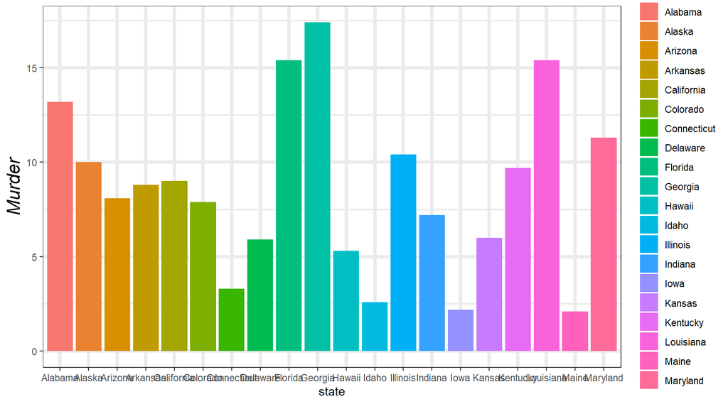

## Stattdessen

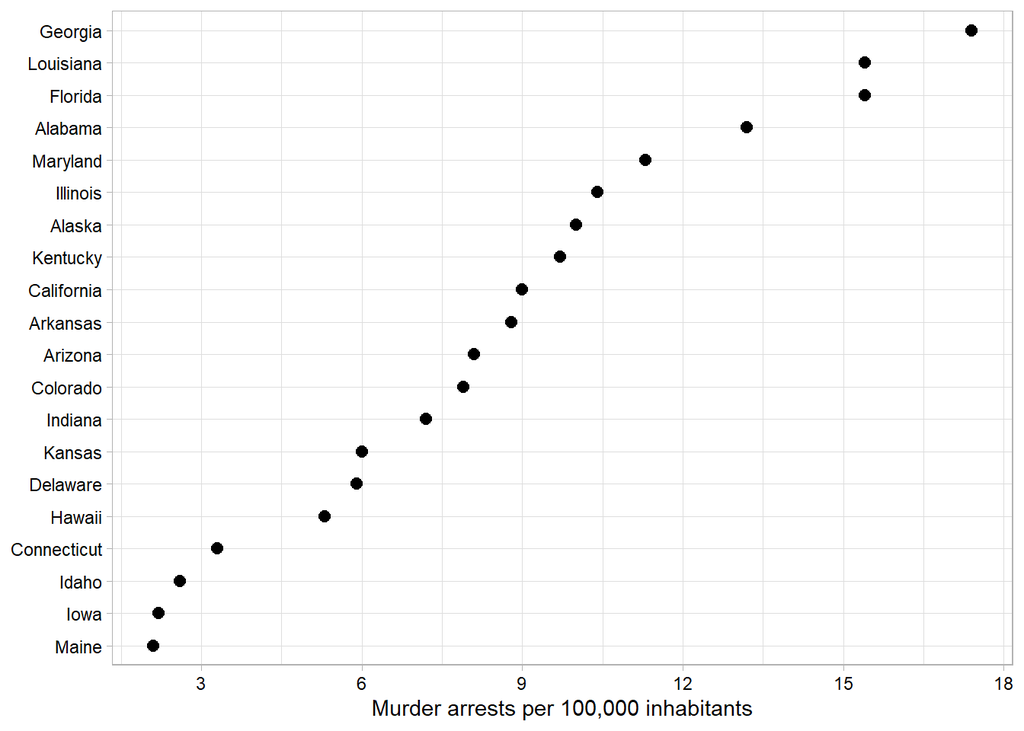

## Hässlich, potenziell schlecht

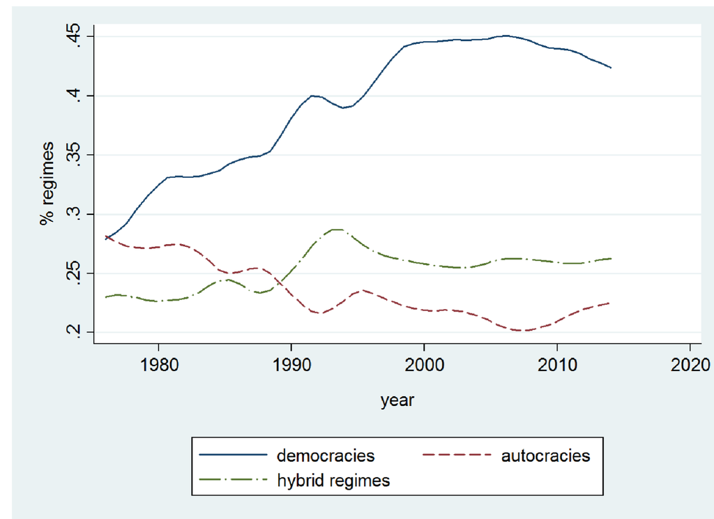

Quelle: [Huq und Ginsburg](https://papers.ssrn.com/sol3/papers.cfm?abstract_id=2901776), S. 16.

## Stattdessen

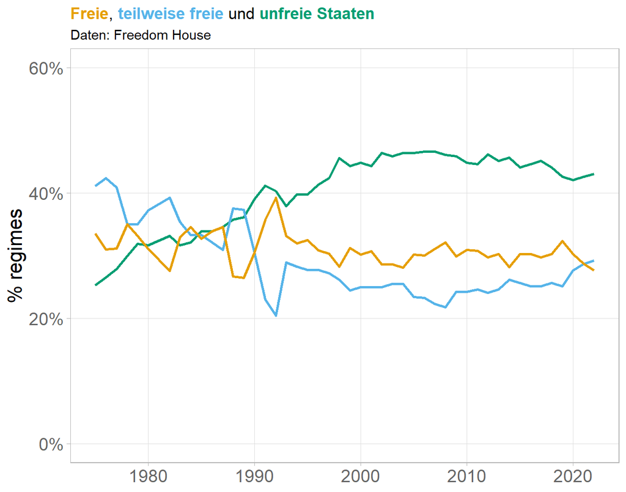

## The wrong, the bad and the ugly

- Hässlich – eine Abbildung, die ästhetische Probleme aufweist, aber ansonsten klar und informativ ist.
- Schlecht – eine Abbildung, die Probleme mit der Darstellung hat; sie kann unklar, verwirrend, übermäßig kompliziert oder irreführend sein.
- Falsch – eine Abbildung, die objektiv falsch ist.

Quelle: [Willke 2019: 2](https://clauswilke.com/dataviz/introduction.html).

## Beispiele für hässlich, schlecht und falsch

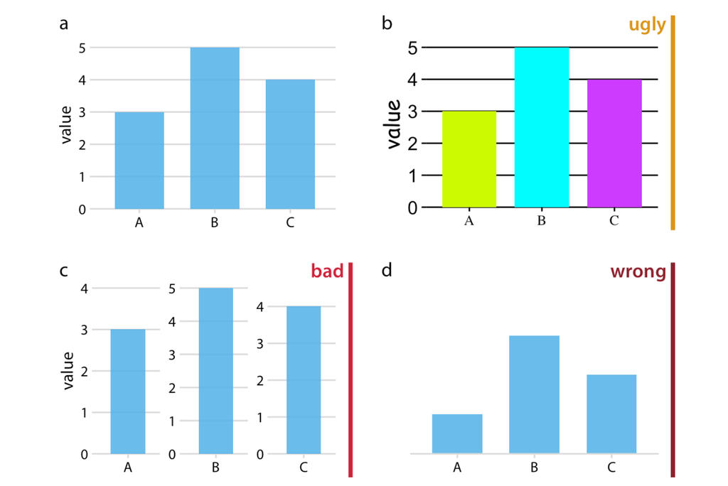

Quelle: [Willke 2019: 3](https://clauswilke.com/dataviz/introduction.html).

## Erste Merkposten

1. Eine Abbildung sollte die Kernaussage klar transportieren.
2. Farben sollten nur eingesetzt werden, wenn sie eine inhaltliche Bedeutung haben.
3. Hintergründe, Hilfslinien, Achsen und Legenden sollten nicht so gestaltet werden, dass sie die meiste Aufmerksamkeit auf sich ziehen.
4. Generell gilt: *Less ink per inch*.
5. Eine Abbildung, bei der die dargestellten Werte nicht nachvollziebar sind, ist immer schlecht und meistens sogar falsch.

## Bitte vermeiden

1. Tortendiagramme mit mehr als drei Tortenstücken<sup>1</sup>
2. Gestapelte Balkendiagramme
3. Dreidimensionale Abbildungen
4. Senkrechte Balkendiagramme mit vielen Kategorien
5. Spezialeffekte (explodierendes Tortendiagramm)
[^1]: Tortendiagramme am besten ganz vermeiden!

## Warum R?

R ist eine kostenfrei nutzbare Programmiersprache, die auf allen gängigen Betriebssystemen läuft. In den Sozialwissenschaften ist R inzwischen extrem verbreitet. Lange Zeit waren gerade die Visualisierungsmöglichkeiten besser als die in Stata.

Es gibt Anwendungen, bei denen andere Software überlegen ist, aber für die meisten Aufgaben, die im Studium anstehen, sollte R spielend ausreichen.

Ein großer Vorteil von R ist, dass zahlreiche Hilfestellungen kostenlos im Web zu finden sind.

## Was wir nicht machen

**Warning**

- Dies ist kein Statistikseminar – es geht um die Visualisierung von Daten!
- Dies ist keine umfassende Einführung in die Nutzung von R, aber ein guter Start.
- Wir decken nur einen kleinen Teil der Möglichkeiten ab, die R zur Datenauswertung und -visualisierung bietet.
- Das ist kein Kurs zur Theorie der Datenvisualisierung.

## Ablauf

*17. April: Einführung*

*24. April: Grundlagen*

*8. Mai: Balkendiagramme*

*15. Mai: Gestaltungsarten – die “Geome”*

*22. Mai: Übungswoche*

*5. Juni: Daten umformen und weitere Darstellungsarten*

## Ablauf

*12. Juni: Funktionen I: Unnötige Wiederholungen vermeiden*

*26. Juni: Funktionen II: Grafiken automatisiert erstellen*

*3. Juli: Trends im Zeitverlauf*

*10. Juli: Lineare Regressionsmodelle und Interaktionen grafisch darstellen*

*17. Juli: Logistische Regression und vorhergesagte Wahrscheinlichkeiten*

## Was Sie tun müssen

1. Sie nehmen regelmäßig teil und wiederholen die Inhalte.
2. An einem Termin müssen Sie eine Übungsaufgabe lösen und in Moodle hochladen (aktive Teilnahme).

## R und RStudio über die Universität laden

[figure not shown]

## Alternative: R auf den eigenen Rechner laden

1. Laden Sie R von [posit.co](https://posit.co/download/rstudio-desktop/) herunter und installieren Sie es.
2. Laden Sie nun ebenfalls RStudio herunter und installieren Sie es.

## Die Startseite (ist anpassbar)

Die Fenster der Startseite lassen sich verschieben (`Tools` $\rightarrow$ `Global Options` $\rightarrow$ `Pane Layout`) und die Farbgestaltung auswählen. Aber Sie sollten immer Zugriff auf die `Console` und das Fenster `Source` haben.

[figure not shown]

## Befehle in die Console eingeben

Die Console können Sie nutzen, um Befehle direkt einzugeben. In Zukunft werden wir das selten tun, weil die dort eingegebenen Befehle mit dem Schließen des Programms verschwinden. Wenn wir eine Variable definieren wollen oder eine Grafik zwischenspeichern wollen, verwenden wir einen nach links weisenden Pfeil `<-`. Die Tastaturkombination ist alt + Bindestrich.

```r
x <- 3
y <- 4

x + x
```

```
[1] 6
```

```r
x * y
```

```
[1] 12
```

```r
x <- "Guten Morgen"
x
```

```
[1] "Guten Morgen"
```

## Vektoren

[^2]: Das kleine “c” vor der Klammer steht für “combine”. Dem werden Sie öfters begegnen.

## Ausblick

Kommende Woche fangen wir an, mit `Skripten` zu arbeiten. Das dient die Ziel, die Analysen reproduzierbar zu halten. Außerdem können Sie sich damit im Lauf des Semesters ein Dokument mit allen Lerninhalten erstellen.

Außerdem werden wir die ersten Grafiken erstellen!

[figure not shown]

Datenvisualisierung